# DensityReport

# Human

### NMD

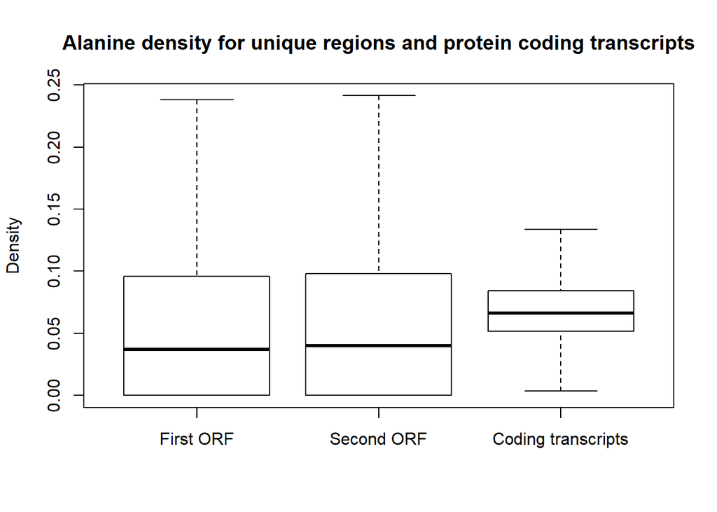

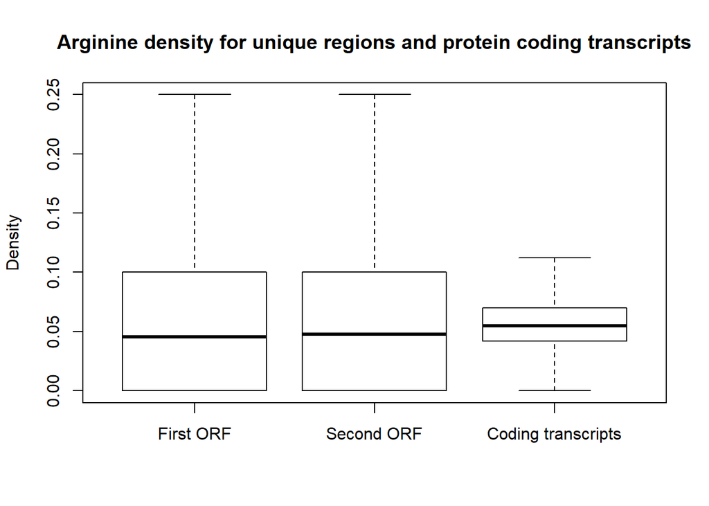

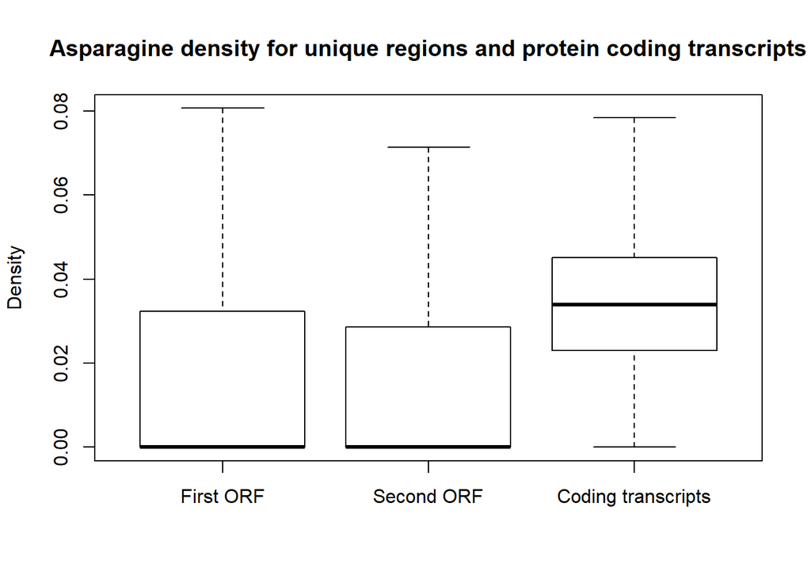

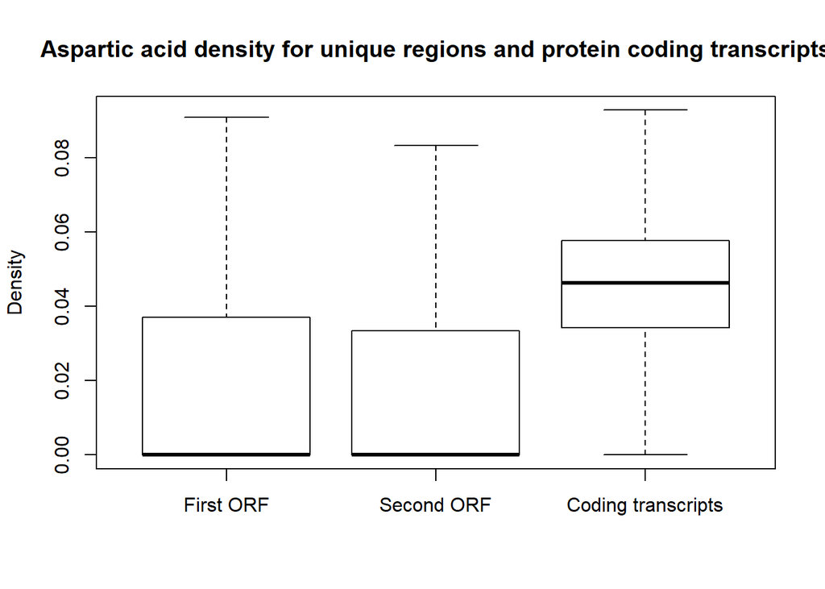

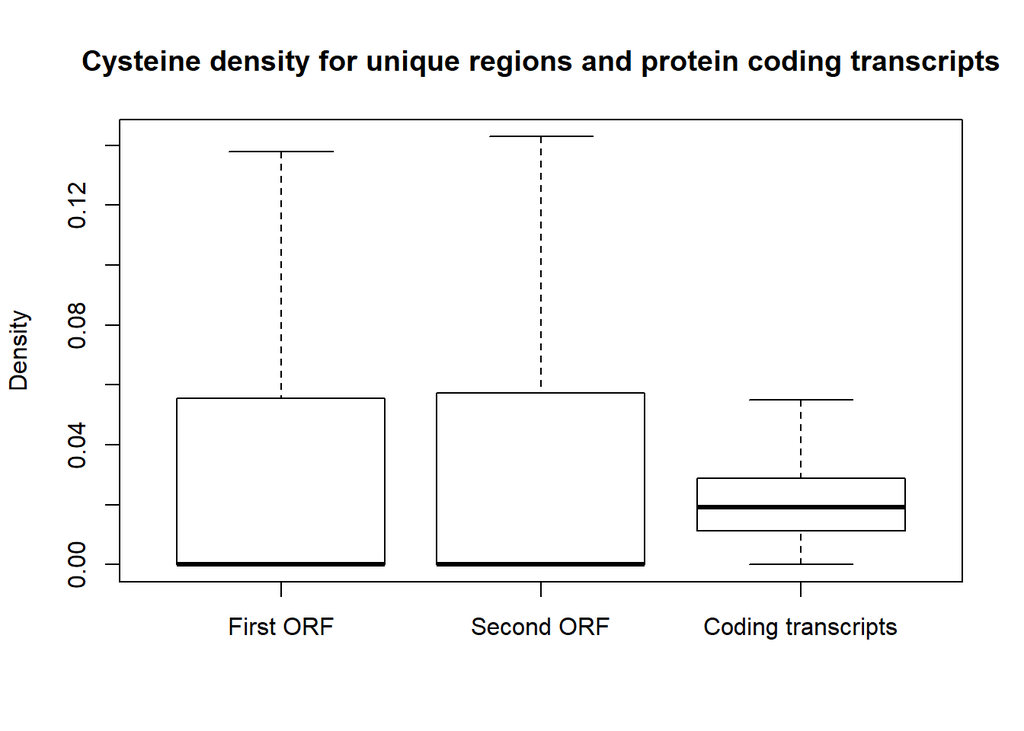

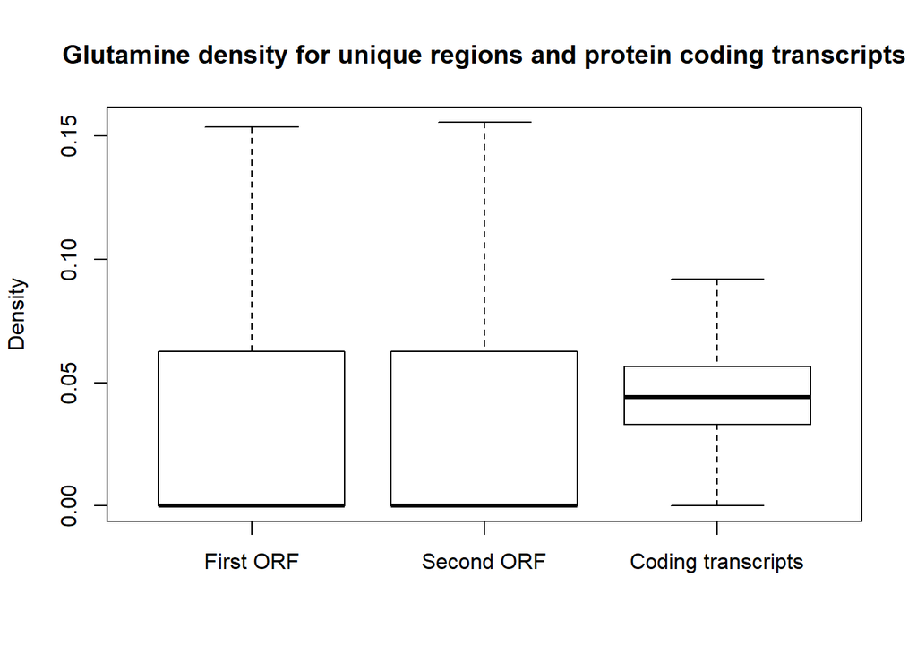

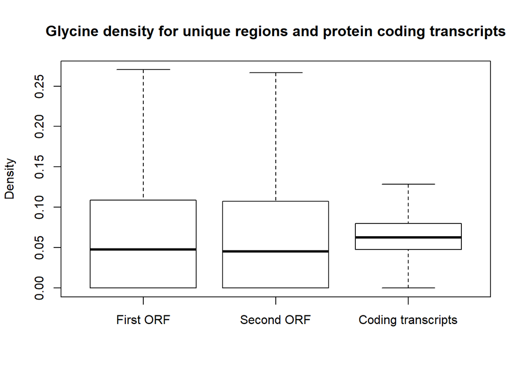

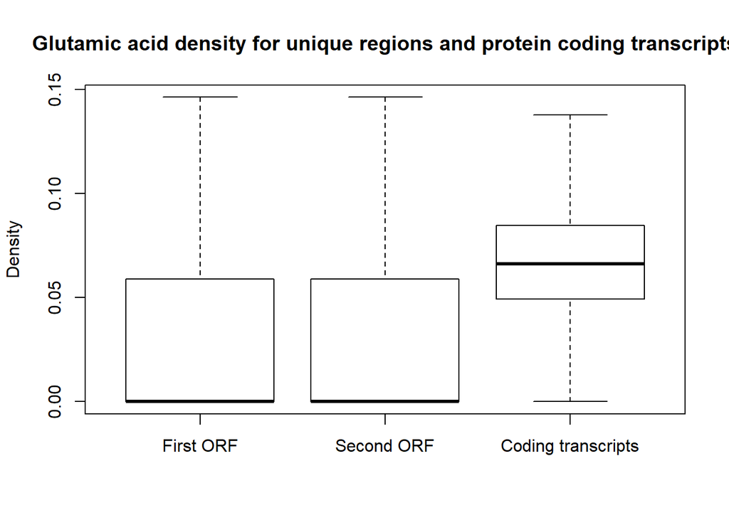

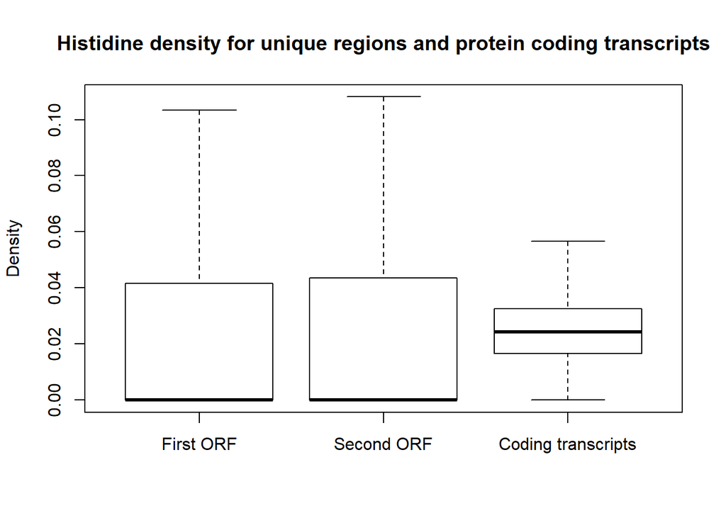

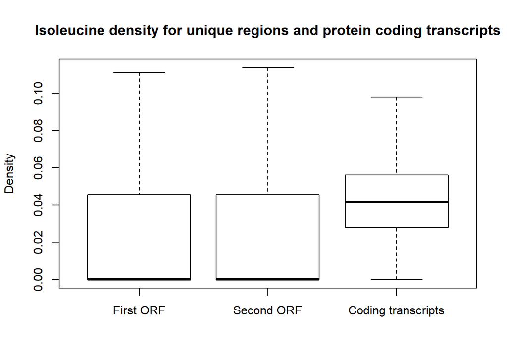

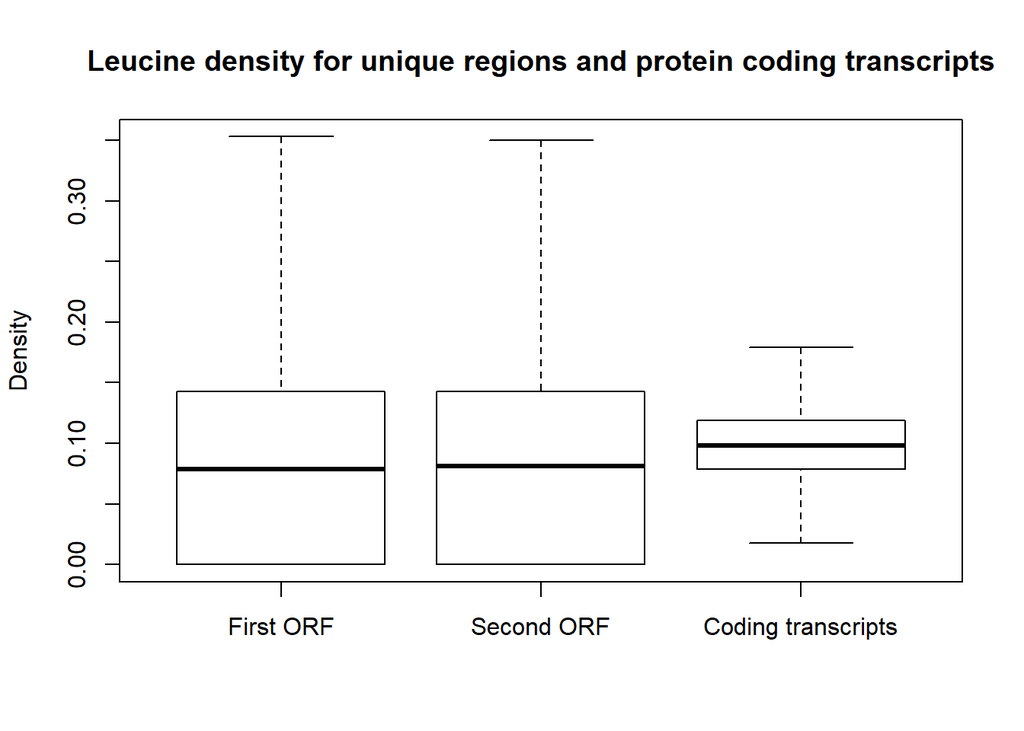

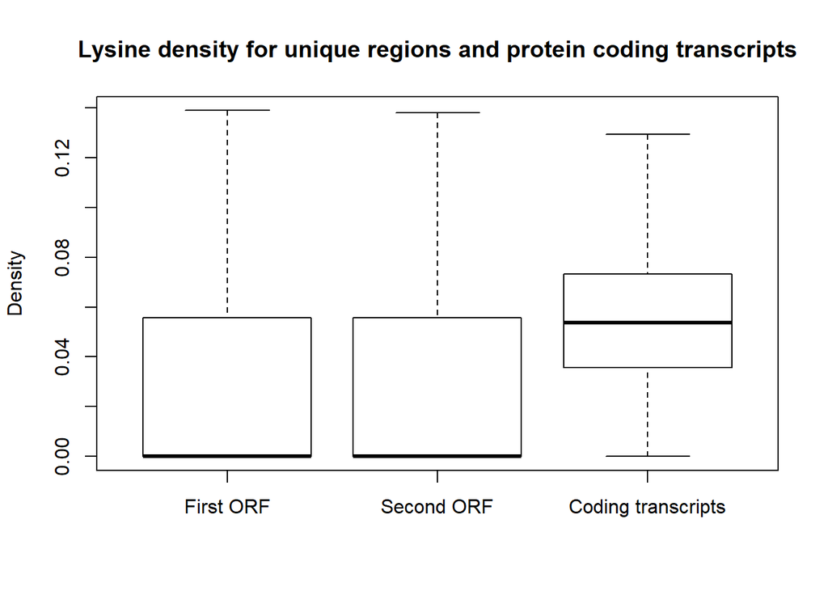

[8 more figures not shown]

### T-test between unique Protein Regions in first ORF and unique Protein Regions in second ORF:

```
## Alananine:
```

```
##
##  Welch Two Sample t-test
##
## data:  NMDdensitiesA[[1]] and NMDdensitiesA[[2]]
## t = 0.80371, df = 12236, p-value = 0.4216
## alternative hypothesis: true difference in means is not equal to 0
## 95 percent confidence interval:
##  -0.002211224  0.005284733
## sample estimates:
##  mean of x  mean of y
## 0.06683314 0.06529638
```

```
## Arginine
```

```
##
##  Welch Two Sample t-test
##
## data:  NMDdensitiesR[[1]] and NMDdensitiesR[[2]]
## t = -1.2634, df = 12606, p-value = 0.2065
## alternative hypothesis: true difference in means is not equal to 0
## 95 percent confidence interval:
##  -0.006475174  0.001399690
## sample estimates:
##  mean of x  mean of y
## 0.07040403 0.07294177
```

```
## Asparagine
```

```
##
##  Welch Two Sample t-test
##
## data:  NMDdensitiesN[[1]] and NMDdensitiesN[[2]]
## t = 1.3374, df = 12028, p-value = 0.1811
## alternative hypothesis: true difference in means is not equal to 0
## 95 percent confidence interval:
##  -0.000784926  0.004156377
## sample estimates:
##  mean of x  mean of y
## 0.02715539 0.02546966
```

```
## Aspartic acid
```

```
##
##  Welch Two Sample t-test
##
## data:  NMDdensitiesD[[1]] and NMDdensitiesD[[2]]
## t = 1.1295, df = 12443, p-value = 0.2587
## alternative hypothesis: true difference in means is not equal to 0
## 95 percent confidence interval:
##  -0.001029355  0.003828878
## sample estimates:
##  mean of x  mean of y
## 0.02794770 0.02654794
```

```
## Cysteine
```

```
##
##  Welch Two Sample t-test
##
## data:  NMDdensitiesC[[1]] and NMDdensitiesC[[2]]
## t = -0.80863, df = 12511, p-value = 0.4187
## alternative hypothesis: true difference in means is not equal to 0
## 95 percent confidence interval:
##  -0.003721451  0.001547724
## sample estimates:
##  mean of x  mean of y
## 0.03805241 0.03913928
```

```
## Glutamine
```

```
##
##  Welch Two Sample t-test
##
## data:  NMDdensitiesQ[[1]] and NMDdensitiesQ[[2]]
## t = -0.29003, df = 12430, p-value = 0.7718
## alternative hypothesis: true difference in means is not equal to 0
## 95 percent confidence interval:
##  -0.002917425  0.002165369
## sample estimates:
##  mean of x  mean of y
## 0.04082117 0.04119720
```

```
## Glycine
```

```
##
##  Welch Two Sample t-test
##
## data:  NMDdensitiesG[[1]] and NMDdensitiesG[[2]]
## t = 1.9606, df = 12139, p-value = 0.04995
## alternative hypothesis: true difference in means is not equal to 0
## 95 percent confidence interval:
##  8.606543e-07 7.326228e-03
## sample estimates:
##  mean of x  mean of y
## 0.07339324 0.06972969
```

```
## Glutamic acid
```

```
##
##  Welch Two Sample t-test
##
## data:  NMDdensitiesE[[1]] and NMDdensitiesE[[2]]
## t = 1.8754, df = 11866, p-value = 0.06077
## alternative hypothesis: true difference in means is not equal to 0
## 95 percent confidence interval:
##  -0.0001272087  0.0057537287
## sample estimates:
##  mean of x  mean of y
## 0.04332999 0.04051673
```

```
## Histidine
```

```
##
##  Welch Two Sample t-test
##
## data:  NMDdensitiesH[[1]] and NMDdensitiesH[[2]]
## t = -1.6493, df = 12468, p-value = 0.0991
## alternative hypothesis: true difference in means is not equal to 0
## 95 percent confidence interval:
##  -0.0041301292  0.0003556426
## sample estimates:
##  mean of x  mean of y
## 0.02954069 0.03142793
```

```
## Isoleucine
```

```
##
##  Welch Two Sample t-test
##
## data:  NMDdensitiesI[[1]] and NMDdensitiesI[[2]]
## t = -0.5929, df = 12453, p-value = 0.5533
## alternative hypothesis: true difference in means is not equal to 0
## 95 percent confidence interval:
##  -0.003425135  0.001834282
## sample estimates:
##  mean of x  mean of y
## 0.03399313 0.03478856
```

```
## Leucine
```

```
##
##  Welch Two Sample t-test
##
## data:  NMDdensitiesL[[1]] and NMDdensitiesL[[2]]
## t = -0.077397, df = 12514, p-value = 0.9383
## alternative hypothesis: true difference in means is not equal to 0
## 95 percent confidence interval:
##  -0.004148154  0.003833017
## sample estimates:
##  mean of x  mean of y
## 0.09664565 0.09680322
```

```
## Lysine
```

```
##
##  Welch Two Sample t-test
##
## data:  NMDdensitiesK[[1]] and NMDdensitiesK[[2]]
## t = 0.22853, df = 12401, p-value = 0.8192
## alternative hypothesis: true difference in means is not equal to 0
## 95 percent confidence interval:
##  -0.002992561  0.003782453
## sample estimates:
##  mean of x  mean of y
## 0.04315702 0.04276208
```

```
## Methionine
```

```
##
##  Welch Two Sample t-test
##
## data:  NMDdensitiesM[[1]] and NMDdensitiesM[[2]]
## t = -2.0508, df = 12613, p-value = 0.04031
## alternative hypothesis: true difference in means is not equal to 0
## 95 percent confidence interval:
##  -0.0103441917 -0.0002337333
## sample estimates:
##  mean of x  mean of y
## 0.05319772 0.05848668
```

```
## Phenylalanine
```

```
##
##  Welch Two Sample t-test
##
## data:  NMDdensitiesF[[1]] and NMDdensitiesF[[2]]
## t = 0.91509, df = 12349, p-value = 0.3602
## alternative hypothesis: true difference in means is not equal to 0
## 95 percent confidence interval:
##  -0.001348258  0.003709423
## sample estimates:
##  mean of x  mean of y
## 0.03674921 0.03556863
```

```
## Proline
```

```
##
##  Welch Two Sample t-test
##
## data:  NMDdensitiesP[[1]] and NMDdensitiesP[[2]]
## t = -0.54198, df = 12556, p-value = 0.5878
## alternative hypothesis: true difference in means is not equal to 0
## 95 percent confidence interval:
##  -0.003952377  0.002240139
## sample estimates:
##  mean of x  mean of y
## 0.06921694 0.07007306
```

```
## Serine
```

```
##
##  Welch Two Sample t-test
##
## data:  NMDdensitiesS[[1]] and NMDdensitiesS[[2]]
## t = 0.26608, df = 12276, p-value = 0.7902
## alternative hypothesis: true difference in means is not equal to 0
## 95 percent confidence interval:
##  -0.003755534  0.004935272
## sample estimates:
##  mean of x  mean of y
## 0.10006324 0.09947337
```

```
## Threonine
```

```
##
##  Welch Two Sample t-test
##
## data:  NMDdensitiesT[[1]] and NMDdensitiesT[[2]]
## t = 1.5875, df = 12276, p-value = 0.1124
## alternative hypothesis: true difference in means is not equal to 0
## 95 percent confidence interval:
##  -0.0005231721  0.0049811363
## sample estimates:
##  mean of x  mean of y
## 0.05131603 0.04908705
```

```
## Tryptophan
```

```
##
##  Welch Two Sample t-test
##
## data:  NMDdensitiesW[[1]] and NMDdensitiesW[[2]]
## t = -0.27261, df = 12315, p-value = 0.7852
## alternative hypothesis: true difference in means is not equal to 0
## 95 percent confidence interval:
##  -0.002554965  0.001931077
## sample estimates:
##  mean of x  mean of y
## 0.02736053 0.02767247
```

```
## Tyrosine
```

```
##
##  Welch Two Sample t-test
##
## data:  NMDdensitiesY[[1]] and NMDdensitiesY[[2]]
## t = 0.24764, df = 12524, p-value = 0.8044
## alternative hypothesis: true difference in means is not equal to 0
## 95 percent confidence interval:
##  -0.001540806  0.001986428
## sample estimates:
##  mean of x  mean of y
## 0.01797266 0.01774985
```

```
## Valine
```

```
##
##  Welch Two Sample t-test
##
## data:  NMDdensitiesV[[1]] and NMDdensitiesV[[2]]
## t = -1.3643, df = 12470, p-value = 0.1725
## alternative hypothesis: true difference in means is not equal to 0
## 95 percent confidence interval:
##  -0.005892829  0.001056153
## sample estimates:
##  mean of x  mean of y
## 0.05285013 0.05526847
```

### T-test between unique Protein Regions in first ORF and protein coding transcripts:

```
## Alananine:
```

```
##
##  Welch Two Sample t-test
##
## data:  NMDdensitiesA[[1]] and NMDdensitiesA[[3]]
## t = -2.3948, df = 6034.4, p-value = 0.01666
## alternative hypothesis: true difference in means is not equal to 0
## 95 percent confidence interval:
##  -0.0062562798 -0.0006241166
## sample estimates:
##  mean of x  mean of y
## 0.06683314 0.07027334
```

```
## Arginine
```

```
##
##  Welch Two Sample t-test
##
## data:  NMDdensitiesR[[1]] and NMDdensitiesR[[3]]
## t = 9.0181, df = 6023.4, p-value < 2.2e-16
## alternative hypothesis: true difference in means is not equal to 0
## 95 percent confidence interval:
##  0.009917175 0.015426343
## sample estimates:
##  mean of x  mean of y
## 0.07040403 0.05773227
```

```
## Asparagine
```

```
##
##  Welch Two Sample t-test
##
## data:  NMDdensitiesN[[1]] and NMDdensitiesN[[3]]
## t = -8.0033, df = 6024.1, p-value = 1.443e-15
## alternative hypothesis: true difference in means is not equal to 0
## 95 percent confidence interval:
##  -0.009617893 -0.005833217
## sample estimates:
##  mean of x  mean of y
## 0.02715539 0.03488094
```

```
## Aspartic acid
```

```
##
##  Welch Two Sample t-test
##
## data:  NMDdensitiesD[[1]] and NMDdensitiesD[[3]]
## t = -20.872, df = 6046, p-value < 2.2e-16
## alternative hypothesis: true difference in means is not equal to 0
## 95 percent confidence interval:
##  -0.02070768 -0.01715175
## sample estimates:
##  mean of x  mean of y
## 0.02794770 0.04687742
```

```
## Cysteine
```

```
##
##  Welch Two Sample t-test
##
## data:  NMDdensitiesC[[1]] and NMDdensitiesC[[3]]
## t = 15.481, df = 6042.9, p-value < 2.2e-16
## alternative hypothesis: true difference in means is not equal to 0
## 95 percent confidence interval:
##  0.01313340 0.01694172
## sample estimates:
##  mean of x  mean of y
## 0.03805241 0.02301486
```

```
## Glutamine
```

```
##
##  Welch Two Sample t-test
##
## data:  NMDdensitiesQ[[1]] and NMDdensitiesQ[[3]]
## t = -6.0468, df = 6052.2, p-value = 1.566e-09
## alternative hypothesis: true difference in means is not equal to 0
## 95 percent confidence interval:
##  -0.007616076 -0.003886865
## sample estimates:
##  mean of x  mean of y
## 0.04082117 0.04657264
```

```
## Glycine
```

```
##
##  Welch Two Sample t-test
##
## data:  NMDdensitiesG[[1]] and NMDdensitiesG[[3]]
## t = 5.0646, df = 6040.6, p-value = 4.214e-07
## alternative hypothesis: true difference in means is not equal to 0
## 95 percent confidence interval:
##  0.004401436 0.009960543
## sample estimates:
##  mean of x  mean of y
## 0.07339324 0.06621225
```

```
## Glutamic acid
```

```
##
##  Welch Two Sample t-test
##
## data:  NMDdensitiesE[[1]] and NMDdensitiesE[[3]]
## t = -22.172, df = 6077.1, p-value < 2.2e-16
## alternative hypothesis: true difference in means is not equal to 0
## 95 percent confidence interval:
##  -0.02814188 -0.02356972
## sample estimates:
##  mean of x  mean of y
## 0.04332999 0.06918578
```

```
## Histidine
```

```
##
##  Welch Two Sample t-test
##
## data:  NMDdensitiesH[[1]] and NMDdensitiesH[[3]]
## t = 4.5997, df = 6020.6, p-value = 4.317e-06
## alternative hypothesis: true difference in means is not equal to 0
## 95 percent confidence interval:
##  0.002198668 0.005464730
## sample estimates:
##  mean of x  mean of y
## 0.02954069 0.02570899
```

```
## Isoleucine
```

```
##
##  Welch Two Sample t-test
##
## data:  NMDdensitiesI[[1]] and NMDdensitiesI[[3]]
## t = -9.0875, df = 6042.5, p-value < 2.2e-16
## alternative hypothesis: true difference in means is not equal to 0
## 95 percent confidence interval:
##  -0.010828830 -0.006985852
## sample estimates:
##  mean of x  mean of y
## 0.03399313 0.04290047
```

```
## Leucine
```

```
##
##  Welch Two Sample t-test
##
## data:  NMDdensitiesL[[1]] and NMDdensitiesL[[3]]
## t = -2.1199, df = 6047.7, p-value = 0.03406
## alternative hypothesis: true difference in means is not equal to 0
## 95 percent confidence interval:
##  -0.0059999996 -0.0002345465
## sample estimates:
##  mean of x  mean of y
## 0.09664565 0.09976292
```

```
## Lysine
```

```
##
##  Welch Two Sample t-test
##
## data:  NMDdensitiesK[[1]] and NMDdensitiesK[[3]]
## t = -10.753, df = 6053.5, p-value < 2.2e-16
## alternative hypothesis: true difference in means is not equal to 0
## 95 percent confidence interval:
##  -0.01618924 -0.01119648
## sample estimates:
##  mean of x  mean of y
## 0.04315702 0.05684988
```

```
## Methionine
```

```
##
##  Welch Two Sample t-test
##
## data:  NMDdensitiesM[[1]] and NMDdensitiesM[[3]]
## t = 15.532, df = 6000, p-value < 2.2e-16
## alternative hypothesis: true difference in means is not equal to 0
## 95 percent confidence interval:
##  0.02426334 0.03127299
## sample estimates:
##  mean of x  mean of y
## 0.05319772 0.02542955
```

```
## Phenylalanine
```

```
##
##  Welch Two Sample t-test
##
## data:  NMDdensitiesF[[1]] and NMDdensitiesF[[3]]
## t = -0.3699, df = 6032.4, p-value = 0.7115
## alternative hypothesis: true difference in means is not equal to 0
## 95 percent confidence interval:
##  -0.002228855  0.001521242
## sample estimates:
##  mean of x  mean of y
## 0.03674921 0.03710302
```

```
## Proline
```

```
##
##  Welch Two Sample t-test
##
## data:  NMDdensitiesP[[1]] and NMDdensitiesP[[3]]
## t = 6.5855, df = 6096.3, p-value = 4.912e-11
## alternative hypothesis: true difference in means is not equal to 0
## 95 percent confidence interval:
##  0.005234081 0.009670951
## sample estimates:
##  mean of x  mean of y
## 0.06921694 0.06176443
```

```
## Serine
```

```
##
##  Welch Two Sample t-test
##
## data:  NMDdensitiesS[[1]] and NMDdensitiesS[[3]]
## t = 12.04, df = 6024.9, p-value < 2.2e-16
## alternative hypothesis: true difference in means is not equal to 0
## 95 percent confidence interval:
##  0.01670825 0.02320764
## sample estimates:
##  mean of x  mean of y
## 0.10006324 0.08010529
```

```
## Threonine
```

```
##
##  Welch Two Sample t-test
##
## data:  NMDdensitiesT[[1]] and NMDdensitiesT[[3]]
## t = -0.41012, df = 6030.7, p-value = 0.6817
## alternative hypothesis: true difference in means is not equal to 0
## 95 percent confidence interval:
##  -0.002489147  0.001627846
## sample estimates:
##  mean of x  mean of y
## 0.05131603 0.05174668
```

```
## Tryptophan
```

```
##
##  Welch Two Sample t-test
##
## data:  NMDdensitiesW[[1]] and NMDdensitiesW[[3]]
## t = 16.743, df = 6001.2, p-value < 2.2e-16
## alternative hypothesis: true difference in means is not equal to 0
## 95 percent confidence interval:
##  0.01257912 0.01591534
## sample estimates:
##  mean of x  mean of y
## 0.02736053 0.01311330
```

```
## Tyrosine
```

```
##
##  Welch Two Sample t-test
##
## data:  NMDdensitiesY[[1]] and NMDdensitiesY[[3]]
## t = -13.796, df = 6056.7, p-value < 2.2e-16
## alternative hypothesis: true difference in means is not equal to 0
## 95 percent confidence interval:
##  -0.010220606 -0.007677344
## sample estimates:
##  mean of x  mean of y
## 0.01797266 0.02692163
```

```
## Valine
```

```
##
##  Welch Two Sample t-test
##
## data:  NMDdensitiesV[[1]] and NMDdensitiesV[[3]]
## t = -5.7122, df = 6019.3, p-value = 1.169e-08
## alternative hypothesis: true difference in means is not equal to 0
## 95 percent confidence interval:
##  -0.009896791 -0.004839487
## sample estimates:
##  mean of x  mean of y
## 0.05285013 0.06021827
```

### T-test between unique Protein Regions in second ORF and protein coding transcripts:

```
## Alananine:
```

```
##
##  Welch Two Sample t-test
##
## data:  NMDdensitiesA[[2]] and NMDdensitiesA[[3]]
## t = -3.921, df = 6712.4, p-value = 8.905e-05
## alternative hypothesis: true difference in means is not equal to 0
## 95 percent confidence interval:
##  -0.007465172 -0.002488733
## sample estimates:
##  mean of x  mean of y
## 0.06529638 0.07027334
```

```
## Arginine
```

```
##
##  Welch Two Sample t-test
##
## data:  NMDdensitiesR[[2]] and NMDdensitiesR[[3]]
## t = 10.559, df = 6680.8, p-value < 2.2e-16
## alternative hypothesis: true difference in means is not equal to 0
## 95 percent confidence interval:
##  0.01238578 0.01803322
## sample estimates:
##  mean of x  mean of y
## 0.07294177 0.05773227
```

```
## Asparagine
```

```
##
##  Welch Two Sample t-test
##
## data:  NMDdensitiesN[[2]] and NMDdensitiesN[[3]]
## t = -11.552, df = 6703.8, p-value < 2.2e-16
## alternative hypothesis: true difference in means is not equal to 0
## 95 percent confidence interval:
##  -0.011008322 -0.007814239
## sample estimates:
##  mean of x  mean of y
## 0.02546966 0.03488094
```

```
## Aspartic acid
```

```
##
##  Welch Two Sample t-test
##
## data:  NMDdensitiesD[[2]] and NMDdensitiesD[[3]]
## t = -23.922, df = 6718.6, p-value < 2.2e-16
## alternative hypothesis: true difference in means is not equal to 0
## 95 percent confidence interval:
##  -0.02199537 -0.01866358
## sample estimates:
##  mean of x  mean of y
## 0.02654794 0.04687742
```

```
## Cysteine
```

```
##
##  Welch Two Sample t-test
##
## data:  NMDdensitiesC[[2]] and NMDdensitiesC[[3]]
## t = 17.259, df = 6710.5, p-value < 2.2e-16
## alternative hypothesis: true difference in means is not equal to 0
## 95 percent confidence interval:
##  0.01429293 0.01795591
## sample estimates:
##  mean of x  mean of y
## 0.03913928 0.02301486
```

```
## Glutamine
```

```
##
##  Welch Two Sample t-test
##
## data:  NMDdensitiesQ[[2]] and NMDdensitiesQ[[3]]
## t = -6.0589, df = 6727.2, p-value = 1.445e-09
## alternative hypothesis: true difference in means is not equal to 0
## 95 percent confidence interval:
##  -0.007114632 -0.003636253
## sample estimates:
##  mean of x  mean of y
## 0.04119720 0.04657264
```

```
## Glycine
```

```
##
##  Welch Two Sample t-test
##
## data:  NMDdensitiesG[[2]] and NMDdensitiesG[[3]]
## t = 2.8707, df = 6725.2, p-value = 0.004109
## alternative hypothesis: true difference in means is not equal to 0
## 95 percent confidence interval:
##  0.001115476 0.005919415
## sample estimates:
##  mean of x  mean of y
## 0.06972969 0.06621225
```

```
## Glutamic acid
```

```
##
##  Welch Two Sample t-test
##
## data:  NMDdensitiesE[[2]] and NMDdensitiesE[[3]]
## t = -30.016, df = 6796.6, p-value < 2.2e-16
## alternative hypothesis: true difference in means is not equal to 0
## 95 percent confidence interval:
##  -0.03054138 -0.02679673
## sample estimates:
##  mean of x  mean of y
## 0.04051673 0.06918578
```

```
## Histidine
```

```
##
##  Welch Two Sample t-test
##
## data:  NMDdensitiesH[[2]] and NMDdensitiesH[[3]]
## t = 7.2628, df = 6685.5, p-value = 4.221e-13
## alternative hypothesis: true difference in means is not equal to 0
## 95 percent confidence interval:
##  0.004175335 0.007262550
## sample estimates:
##  mean of x  mean of y
## 0.03142793 0.02570899
```

```
## Isoleucine
```

```
##
##  Welch Two Sample t-test
##
## data:  NMDdensitiesI[[2]] and NMDdensitiesI[[3]]
## t = -8.8034, df = 6713.6, p-value < 2.2e-16
## alternative hypothesis: true difference in means is not equal to 0
## 95 percent confidence interval:
##  -0.009918252 -0.006305577
## sample estimates:
##  mean of x  mean of y
## 0.03478856 0.04290047
```

```
## Leucine
```

```
##
##  Welch Two Sample t-test
##
## data:  NMDdensitiesL[[2]] and NMDdensitiesL[[3]]
## t = -2.0894, df = 6716, p-value = 0.03671
## alternative hypothesis: true difference in means is not equal to 0
## 95 percent confidence interval:
##  -0.0057365642 -0.0001828452
## sample estimates:
##  mean of x  mean of y
## 0.09680322 0.09976292
```

```
## Lysine
```

```
##
##  Welch Two Sample t-test
##
## data:  NMDdensitiesK[[2]] and NMDdensitiesK[[3]]
## t = -11.972, df = 6730.6, p-value < 2.2e-16
## alternative hypothesis: true difference in means is not equal to 0
## 95 percent confidence interval:
##  -0.01639461 -0.01178100
## sample estimates:
##  mean of x  mean of y
## 0.04276208 0.05684988
```

```
## Methionine
```

```
##
##  Welch Two Sample t-test
##
## data:  NMDdensitiesM[[2]] and NMDdensitiesM[[3]]
## t = 17.758, df = 6655.5, p-value < 2.2e-16
## alternative hypothesis: true difference in means is not equal to 0
## 95 percent confidence interval:
##  0.02940783 0.03670643
## sample estimates:
##  mean of x  mean of y
## 0.05848668 0.02542955
```

```
## Phenylalanine
```

```
##
##  Welch Two Sample t-test
##
## data:  NMDdensitiesF[[2]] and NMDdensitiesF[[3]]
## t = -1.7629, df = 6705.3, p-value = 0.07795
## alternative hypothesis: true difference in means is not equal to 0
## 95 percent confidence interval:
##  -0.0032405587  0.0001717811
## sample estimates:
##  mean of x  mean of y
## 0.03556863 0.03710302
```

```
## Proline
```

```
##
##  Welch Two Sample t-test
##
## data:  NMDdensitiesP[[2]] and NMDdensitiesP[[3]]
## t = 7.4642, df = 6768.4, p-value = 9.43e-14
## alternative hypothesis: true difference in means is not equal to 0
## 95 percent confidence interval:
##  0.006126553 0.010490718
## sample estimates:
##  mean of x  mean of y
## 0.07007306 0.06176443
```

```
## Serine
```

```
##
##  Welch Two Sample t-test
##
## data:  NMDdensitiesS[[2]] and NMDdensitiesS[[3]]
## t = 13.097, df = 6697.6, p-value < 2.2e-16
## alternative hypothesis: true difference in means is not equal to 0
## 95 percent confidence interval:
##  0.01646905 0.02226710
## sample estimates:
##  mean of x  mean of y
## 0.09947337 0.08010529
```

```
## Threonine
```

```
##
##  Welch Two Sample t-test
##
## data:  NMDdensitiesT[[2]] and NMDdensitiesT[[3]]
## t = -2.8384, df = 6705.7, p-value = 0.004548
## alternative hypothesis: true difference in means is not equal to 0
## 95 percent confidence interval:
##  -0.0044964902 -0.0008227759
## sample estimates:
##  mean of x  mean of y
## 0.04908705 0.05174668
```

```
## Tryptophan
```

```
##
##  Welch Two Sample t-test
##
## data:  NMDdensitiesW[[2]] and NMDdensitiesW[[3]]
## t = 18.988, df = 6664, p-value < 2.2e-16
## alternative hypothesis: true difference in means is not equal to 0
## 95 percent confidence interval:
##  0.01305607 0.01606228
## sample estimates:
##  mean of x  mean of y
## 0.02767247 0.01311330
```

```
## Tyrosine
```

```
##
##  Welch Two Sample t-test
##
## data:  NMDdensitiesY[[2]] and NMDdensitiesY[[3]]
## t = -14.61, df = 6725.9, p-value < 2.2e-16
## alternative hypothesis: true difference in means is not equal to 0
## 95 percent confidence interval:
##  -0.010402404 -0.007941167
## sample estimates:
##  mean of x  mean of y
## 0.01774985 0.02692163
```

```
## Valine
```

```
##
##  Welch Two Sample t-test
##
## data:  NMDdensitiesV[[2]] and NMDdensitiesV[[3]]
## t = -4.0564, df = 6683.8, p-value = 5.041e-05
## alternative hypothesis: true difference in means is not equal to 0
## 95 percent confidence interval:
##  -0.007341895 -0.002557707
## sample estimates:
##  mean of x  mean of y
## 0.05526847 0.06021827
```

### RI

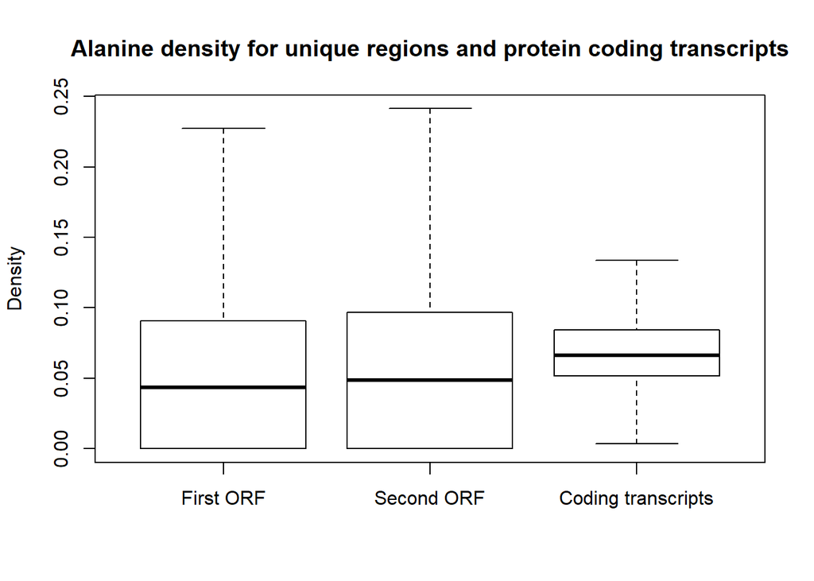

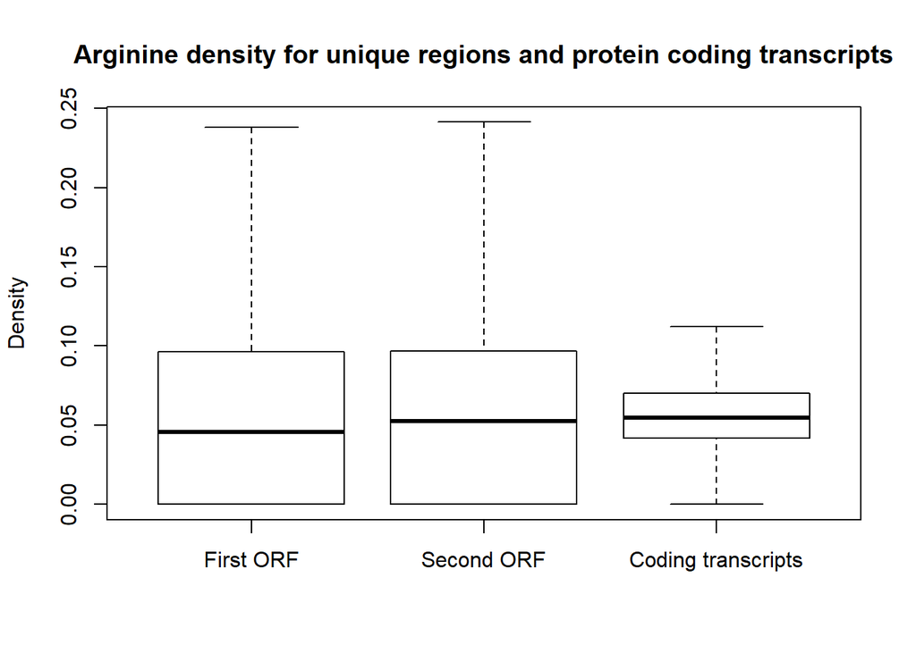

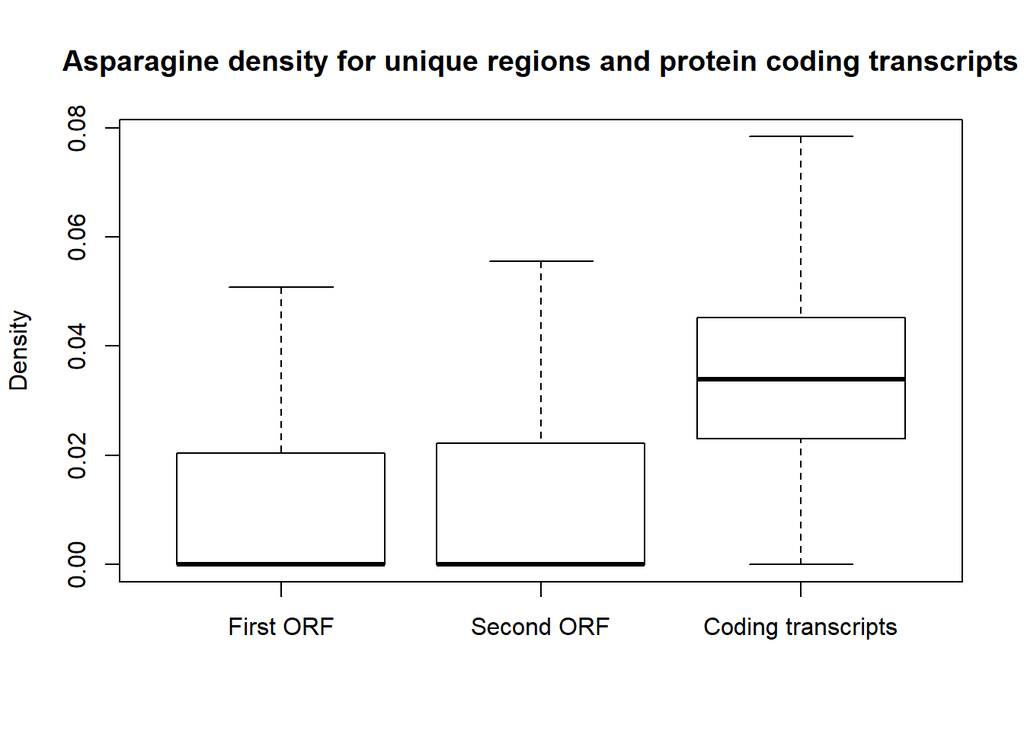

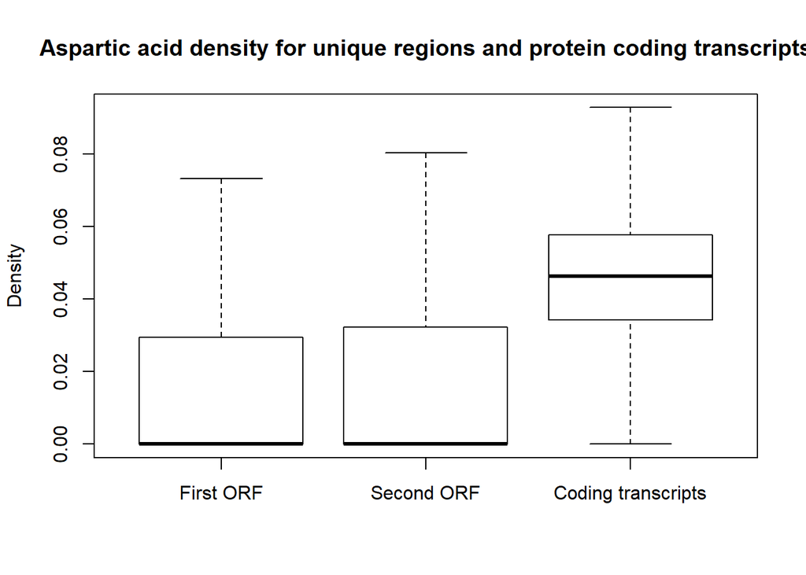

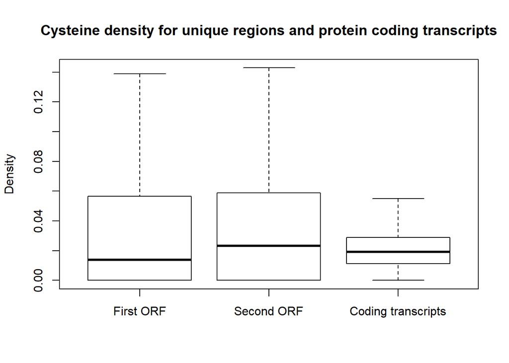

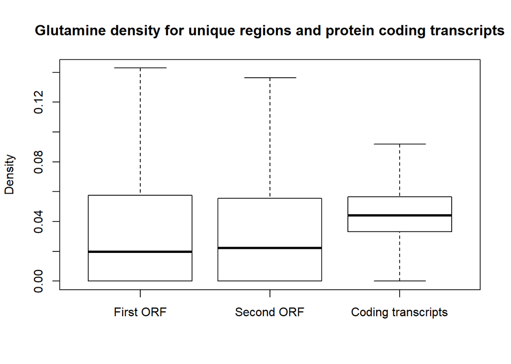

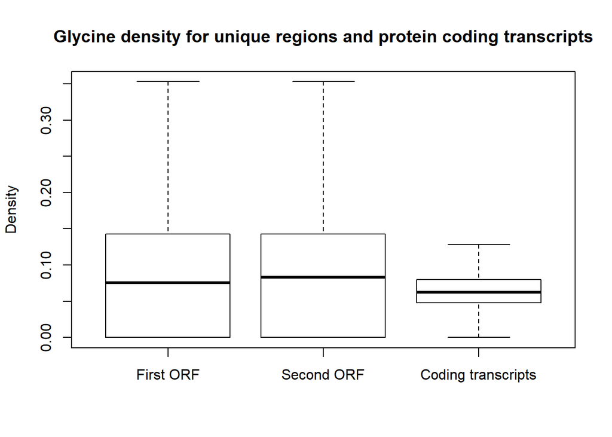

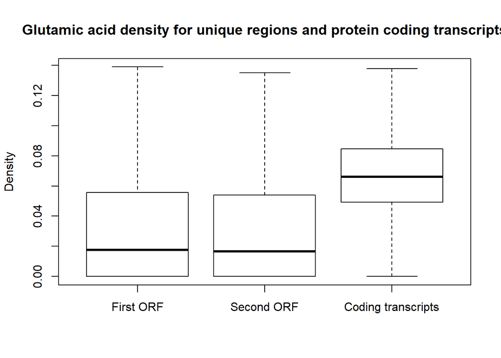

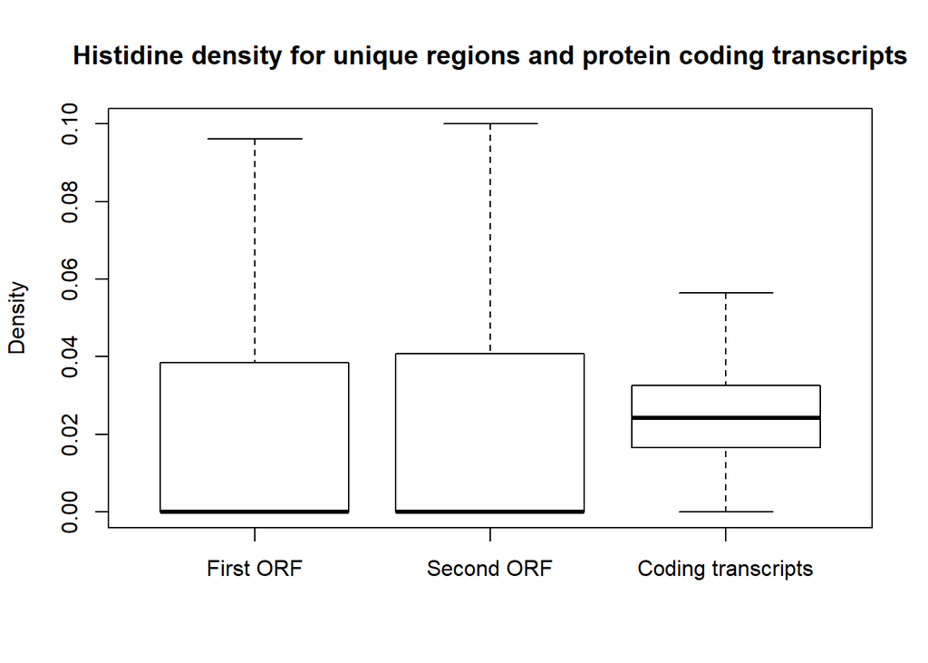

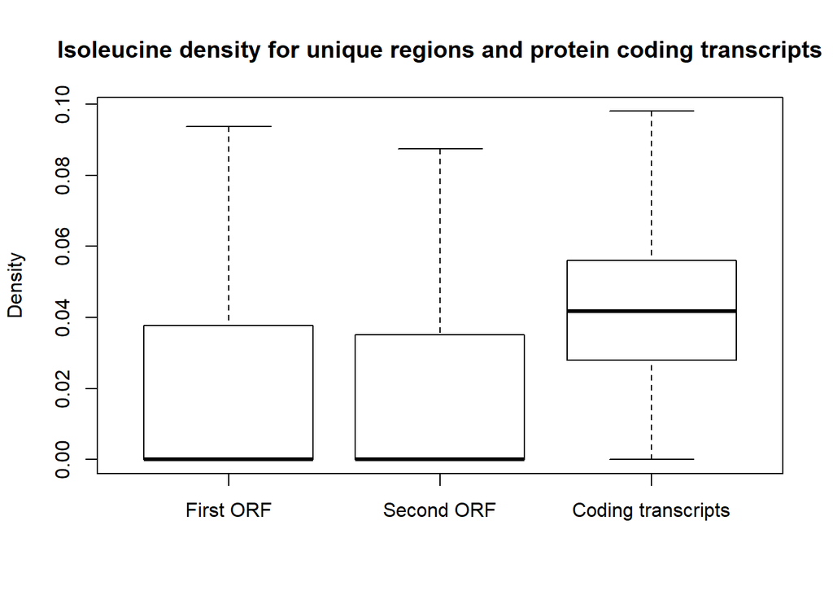

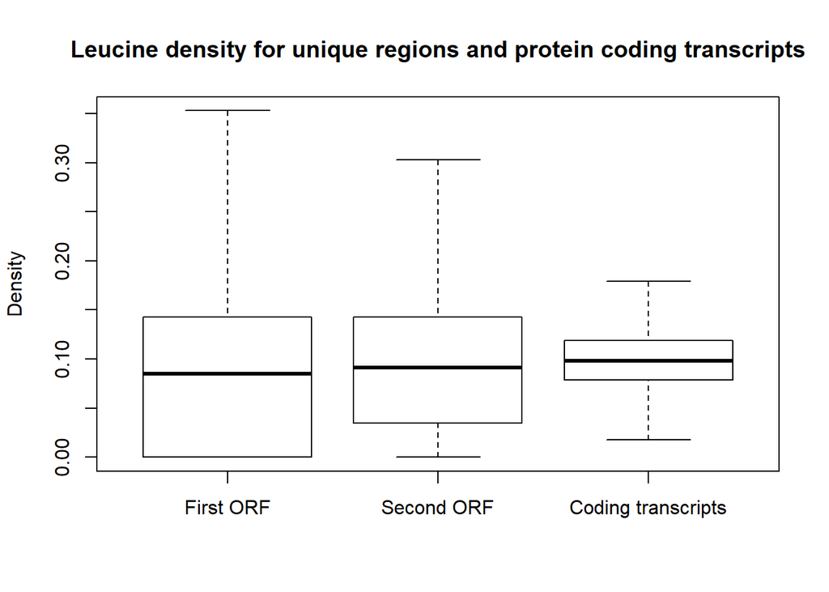

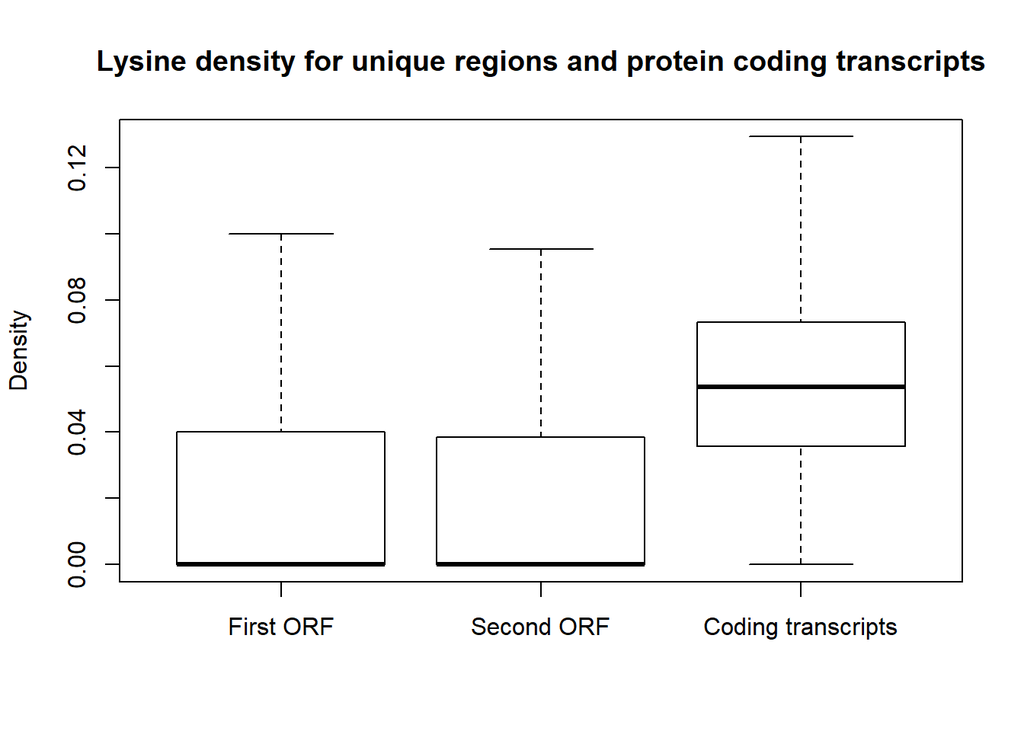

[8 more figures not shown]

### T-test between unique Protein Regions in first ORF and unique Protein Regions in second ORF:

```
## Alananine:
```

```
##
##  Welch Two Sample t-test
##
## data:  RIdensitiesA[[1]] and RIdensitiesA[[2]]
## t = 1.205, df = 8345.2, p-value = 0.2282
## alternative hypothesis: true difference in means is not equal to 0
## 95 percent confidence interval:
##  -0.001379134  0.005780354
## sample estimates:
##  mean of x  mean of y
## 0.06447407 0.06227346
```

```
## Arginine
```

```
##
##  Welch Two Sample t-test
##
## data:  RIdensitiesR[[1]] and RIdensitiesR[[2]]
## t = 0.19552, df = 9473.7, p-value = 0.845
## alternative hypothesis: true difference in means is not equal to 0
## 95 percent confidence interval:
##  -0.004173444  0.005098263
## sample estimates:
##  mean of x  mean of y
## 0.07154685 0.07108444
```

```
## Asparagine
```

```
##
##  Welch Two Sample t-test
##
## data:  RIdensitiesN[[1]] and RIdensitiesN[[2]]
## t = 2.7604, df = 7502.3, p-value = 0.005788
## alternative hypothesis: true difference in means is not equal to 0
## 95 percent confidence interval:
##  0.0009881483 0.0058302487
## sample estimates:
##  mean of x  mean of y
## 0.02099398 0.01758479
```

```
## Aspartic acid
```

```
##
##  Welch Two Sample t-test
##
## data:  RIdensitiesD[[1]] and RIdensitiesD[[2]]
## t = -0.99244, df = 9853.1, p-value = 0.321
## alternative hypothesis: true difference in means is not equal to 0
## 95 percent confidence interval:
##  -0.003508659  0.001150012
## sample estimates:
##  mean of x  mean of y
## 0.02215521 0.02333454
```

```
## Cysteine
```

```
##
##  Welch Two Sample t-test
##
## data:  RIdensitiesC[[1]] and RIdensitiesC[[2]]
## t = 0.038886, df = 9122.9, p-value = 0.969
## alternative hypothesis: true difference in means is not equal to 0
## 95 percent confidence interval:
##  -0.002555475  0.002658917
## sample estimates:
##  mean of x  mean of y
## 0.03884688 0.03879516
```

```
## Glutamine
```

```
##
##  Welch Two Sample t-test
##
## data:  RIdensitiesQ[[1]] and RIdensitiesQ[[2]]
## t = 2.5914, df = 8529.5, p-value = 0.009575
## alternative hypothesis: true difference in means is not equal to 0
## 95 percent confidence interval:
##  0.001000124 0.007212600
## sample estimates:
##  mean of x  mean of y
## 0.04173546 0.03762910
```

```
## Glycine
```

```
##
##  Welch Two Sample t-test
##
## data:  RIdensitiesG[[1]] and RIdensitiesG[[2]]
## t = -0.75639, df = 9507.4, p-value = 0.4494
## alternative hypothesis: true difference in means is not equal to 0
## 95 percent confidence interval:
##  -0.005919266  0.002623041
## sample estimates:
##  mean of x  mean of y
## 0.09576158 0.09740969
```

```
## Glutamic acid
```

```
##
##  Welch Two Sample t-test
##
## data:  RIdensitiesE[[1]] and RIdensitiesE[[2]]
## t = 3.3362, df = 8587, p-value = 0.0008528
## alternative hypothesis: true difference in means is not equal to 0
## 95 percent confidence interval:
##  0.002767478 0.010652628
## sample estimates:
##  mean of x  mean of y
## 0.04758084 0.04087079
```

```
## Histidine
```

```
##
##  Welch Two Sample t-test
##
## data:  RIdensitiesH[[1]] and RIdensitiesH[[2]]
## t = -1.2079, df = 9568.5, p-value = 0.2271
## alternative hypothesis: true difference in means is not equal to 0
## 95 percent confidence interval:
##  -0.0031660476  0.0007518622
## sample estimates:
##  mean of x  mean of y
## 0.02541091 0.02661800
```

```
## Isoleucine
```

```
##
##  Welch Two Sample t-test
##
## data:  RIdensitiesI[[1]] and RIdensitiesI[[2]]
## t = 1.6328, df = 9366.2, p-value = 0.1025
## alternative hypothesis: true difference in means is not equal to 0
## 95 percent confidence interval:
##  -0.000362185  0.003974537
## sample estimates:
##  mean of x  mean of y
## 0.02827956 0.02647338
```

```
## Leucine
```

```
##
##  Welch Two Sample t-test
##
## data:  RIdensitiesL[[1]] and RIdensitiesL[[2]]
## t = -3.3114, df = 9542.3, p-value = 0.0009317
## alternative hypothesis: true difference in means is not equal to 0
## 95 percent confidence interval:
##  -0.009897701 -0.002536956
## sample estimates:
##  mean of x  mean of y
## 0.09398336 0.10020069
```

```
## Lysine
```

```
##
##  Welch Two Sample t-test
##
## data:  RIdensitiesK[[1]] and RIdensitiesK[[2]]
## t = 1.1917, df = 9605.4, p-value = 0.2334
## alternative hypothesis: true difference in means is not equal to 0
## 95 percent confidence interval:
##  -0.001404722  0.005761286
## sample estimates:
##  mean of x  mean of y
## 0.03570707 0.03352878
```

```
## Methionine
```

```
##
##  Welch Two Sample t-test
##
## data:  RIdensitiesM[[1]] and RIdensitiesM[[2]]
## t = 0.71615, df = 9397.1, p-value = 0.4739
## alternative hypothesis: true difference in means is not equal to 0
## 95 percent confidence interval:
##  -0.003036249  0.006531873
## sample estimates:
##  mean of x  mean of y
## 0.04585946 0.04411165
```

```
## Phenylalanine
```

```
##
##  Welch Two Sample t-test
##
## data:  RIdensitiesF[[1]] and RIdensitiesF[[2]]
## t = -0.867, df = 9779.6, p-value = 0.386
## alternative hypothesis: true difference in means is not equal to 0
## 95 percent confidence interval:
##  -0.003745786  0.001448399
## sample estimates:
##  mean of x  mean of y
## 0.03652595 0.03767464
```

```
## Proline
```

```
##
##  Welch Two Sample t-test
##
## data:  RIdensitiesP[[1]] and RIdensitiesP[[2]]
## t = -4.8726, df = 9777, p-value = 1.118e-06
## alternative hypothesis: true difference in means is not equal to 0
## 95 percent confidence interval:
##  -0.011889550 -0.005067805
## sample estimates:
##  mean of x  mean of y
## 0.08009774 0.08857642
```

```
## Serine
```

```
##
##  Welch Two Sample t-test
##
## data:  RIdensitiesS[[1]] and RIdensitiesS[[2]]
## t = -3.0427, df = 9390.2, p-value = 0.002351
## alternative hypothesis: true difference in means is not equal to 0
## 95 percent confidence interval:
##  -0.010622690 -0.002298433
## sample estimates:
## mean of x mean of y
## 0.0941355 0.1005961
```

```
## Threonine
```

```
##
##  Welch Two Sample t-test
##
## data:  RIdensitiesT[[1]] and RIdensitiesT[[2]]
## t = 0.42072, df = 8692, p-value = 0.674
## alternative hypothesis: true difference in means is not equal to 0
## 95 percent confidence interval:
##  -0.002143094  0.003314435
## sample estimates:
##  mean of x  mean of y
## 0.04401603 0.04343036
```

```
## Tryptophan
```

```
##
##  Welch Two Sample t-test
##
## data:  RIdensitiesW[[1]] and RIdensitiesW[[2]]
## t = -1.1369, df = 8874.5, p-value = 0.2556
## alternative hypothesis: true difference in means is not equal to 0
## 95 percent confidence interval:
##  -0.003790358  0.001007542
## sample estimates:
##  mean of x  mean of y
## 0.02644784 0.02783925
```

```
## Tyrosine
```

```
##
##  Welch Two Sample t-test
##
## data:  RIdensitiesY[[1]] and RIdensitiesY[[2]]
## t = 2.1816, df = 9270.3, p-value = 0.02917
## alternative hypothesis: true difference in means is not equal to 0
## 95 percent confidence interval:
##  0.0001998828 0.0037402036
## sample estimates:
##  mean of x  mean of y
## 0.01803915 0.01606911
```

```
## Valine
```

```
##
##  Welch Two Sample t-test
##
## data:  RIdensitiesV[[1]] and RIdensitiesV[[2]]
## t = 1.18, df = 8890.6, p-value = 0.238
## alternative hypothesis: true difference in means is not equal to 0
## 95 percent confidence interval:
##  -0.001654777  0.006660499
## sample estimates:
##  mean of x  mean of y
## 0.06840256 0.06589970
```

### T-test between unique Protein Regions in first ORF and protein coding transcripts:

```
## Alananine:
```

```
##
##  Welch Two Sample t-test
##
## data:  RIdensitiesA[[1]] and RIdensitiesA[[3]]
## t = -3.8368, df = 4655.9, p-value = 0.0001263
## alternative hypothesis: true difference in means is not equal to 0
## 95 percent confidence interval:
##  -0.008762473 -0.002836058
## sample estimates:
##  mean of x  mean of y
## 0.06447407 0.07027334
```

```
## Arginine
```

```
##
##  Welch Two Sample t-test
##
## data:  RIdensitiesR[[1]] and RIdensitiesR[[3]]
## t = 7.7019, df = 4638.5, p-value = 1.628e-14
## alternative hypothesis: true difference in means is not equal to 0
## 95 percent confidence interval:
##  0.01029816 0.01733099
## sample estimates:
##  mean of x  mean of y
## 0.07154685 0.05773227
```

```
## Asparagine
```

```
##
##  Welch Two Sample t-test
##
## data:  RIdensitiesN[[1]] and RIdensitiesN[[3]]
## t = -12.975, df = 4645.7, p-value < 2.2e-16
## alternative hypothesis: true difference in means is not equal to 0
## 95 percent confidence interval:
##  -0.01598518 -0.01178873
## sample estimates:
##  mean of x  mean of y
## 0.02099398 0.03488094
```

```
## Aspartic acid
```

```
##
##  Welch Two Sample t-test
##
## data:  RIdensitiesD[[1]] and RIdensitiesD[[3]]
## t = -29.123, df = 4676.3, p-value < 2.2e-16
## alternative hypothesis: true difference in means is not equal to 0
## 95 percent confidence interval:
##  -0.02638645 -0.02305795
## sample estimates:
##  mean of x  mean of y
## 0.02215521 0.04687742
```

```
## Cysteine
```

```
##
##  Welch Two Sample t-test
##
## data:  RIdensitiesC[[1]] and RIdensitiesC[[3]]
## t = 15.168, df = 4660, p-value < 2.2e-16
## alternative hypothesis: true difference in means is not equal to 0
## 95 percent confidence interval:
##  0.01378575 0.01787829
## sample estimates:
##  mean of x  mean of y
## 0.03884688 0.02301486
```

```
## Glutamine
```

```
##
##  Welch Two Sample t-test
##
## data:  RIdensitiesQ[[1]] and RIdensitiesQ[[3]]
## t = -3.7317, df = 4647.9, p-value = 0.0001924
## alternative hypothesis: true difference in means is not equal to 0
## 95 percent confidence interval:
##  -0.007378395 -0.002295956
## sample estimates:
##  mean of x  mean of y
## 0.04173546 0.04657264
```

```
## Glycine
```

```
##
##  Welch Two Sample t-test
##
## data:  RIdensitiesG[[1]] and RIdensitiesG[[3]]
## t = 17.936, df = 4652.6, p-value < 2.2e-16
## alternative hypothesis: true difference in means is not equal to 0
## 95 percent confidence interval:
##  0.02631939 0.03277928
## sample estimates:
##  mean of x  mean of y
## 0.09576158 0.06621225
```

```
## Glutamic acid
```

```
##
##  Welch Two Sample t-test
##
## data:  RIdensitiesE[[1]] and RIdensitiesE[[3]]
## t = -13.175, df = 4655.7, p-value < 2.2e-16
## alternative hypothesis: true difference in means is not equal to 0
## 95 percent confidence interval:
##  -0.02481992 -0.01838997
## sample estimates:
##  mean of x  mean of y
## 0.04758084 0.06918578
```

```
## Histidine
```

```
##
##  Welch Two Sample t-test
##
## data:  RIdensitiesH[[1]] and RIdensitiesH[[3]]
## t = -0.39729, df = 4656.7, p-value = 0.6912
## alternative hypothesis: true difference in means is not equal to 0
## 95 percent confidence interval:
##  -0.001769009  0.001172844
## sample estimates:
##  mean of x  mean of y
## 0.02541091 0.02570899
```

```
## Isoleucine
```

```
##
##  Welch Two Sample t-test
##
## data:  RIdensitiesI[[1]] and RIdensitiesI[[3]]
## t = -17.193, df = 4682.3, p-value < 2.2e-16
## alternative hypothesis: true difference in means is not equal to 0
## 95 percent confidence interval:
##  -0.01628811 -0.01295372
## sample estimates:
##  mean of x  mean of y
## 0.02827956 0.04290047
```

```
## Leucine
```

```
##
##  Welch Two Sample t-test
##
## data:  RIdensitiesL[[1]] and RIdensitiesL[[3]]
## t = -4.0831, df = 4674.5, p-value = 4.518e-05
## alternative hypothesis: true difference in means is not equal to 0
## 95 percent confidence interval:
##  -0.008554587 -0.003004535
## sample estimates:
##  mean of x  mean of y
## 0.09398336 0.09976292
```

```
## Lysine
```

```
##
##  Welch Two Sample t-test
##
## data:  RIdensitiesK[[1]] and RIdensitiesK[[3]]
## t = -15.472, df = 4667.2, p-value < 2.2e-16
## alternative hypothesis: true difference in means is not equal to 0
## 95 percent confidence interval:
##  -0.02382192 -0.01846371
## sample estimates:
##  mean of x  mean of y
## 0.03570707 0.05684988
```

```
## Methionine
```

```
##
##  Welch Two Sample t-test
##
## data:  RIdensitiesM[[1]] and RIdensitiesM[[3]]
## t = 10.952, df = 4632.2, p-value < 2.2e-16
## alternative hypothesis: true difference in means is not equal to 0
## 95 percent confidence interval:
##  0.01677276 0.02408705
## sample estimates:
##  mean of x  mean of y
## 0.04585946 0.02542955
```

```
## Phenylalanine
```

```
##
##  Welch Two Sample t-test
##
## data:  RIdensitiesF[[1]] and RIdensitiesF[[3]]
## t = -0.59947, df = 4657.9, p-value = 0.5489
## alternative hypothesis: true difference in means is not equal to 0
## 95 percent confidence interval:
##  -0.002464279  0.001310144
## sample estimates:
##  mean of x  mean of y
## 0.03652595 0.03710302
```

```
## Proline
```

```
##
##  Welch Two Sample t-test
##
## data:  RIdensitiesP[[1]] and RIdensitiesP[[3]]
## t = 14.469, df = 4689.4, p-value < 2.2e-16
## alternative hypothesis: true difference in means is not equal to 0
## 95 percent confidence interval:
##  0.01584930 0.02081732
## sample estimates:
##  mean of x  mean of y
## 0.08009774 0.06176443
```

```
## Serine
```

```
##
##  Welch Two Sample t-test
##
## data:  RIdensitiesS[[1]] and RIdensitiesS[[3]]
## t = 8.6288, df = 4654, p-value < 2.2e-16
## alternative hypothesis: true difference in means is not equal to 0
## 95 percent confidence interval:
##  0.01084255 0.01721787
## sample estimates:
##  mean of x  mean of y
## 0.09413550 0.08010529
```

```
## Threonine
```

```
##
##  Welch Two Sample t-test
##
## data:  RIdensitiesT[[1]] and RIdensitiesT[[3]]
## t = -6.8594, df = 4651.9, p-value = 7.823e-12
## alternative hypothesis: true difference in means is not equal to 0
## 95 percent confidence interval:
##  -0.009940145 -0.005521152
## sample estimates:
##  mean of x  mean of y
## 0.04401603 0.05174668
```

```
## Tryptophan
```

```
##
##  Welch Two Sample t-test
##
## data:  RIdensitiesW[[1]] and RIdensitiesW[[3]]
## t = 13.645, df = 4630.4, p-value < 2.2e-16
## alternative hypothesis: true difference in means is not equal to 0
## 95 percent confidence interval:
##  0.01141866 0.01525043
## sample estimates:
##  mean of x  mean of y
## 0.02644784 0.01311330
```

```
## Tyrosine
```

```
##
##  Welch Two Sample t-test
##
## data:  RIdensitiesY[[1]] and RIdensitiesY[[3]]
## t = -12.688, df = 4668.8, p-value < 2.2e-16
## alternative hypothesis: true difference in means is not equal to 0
## 95 percent confidence interval:
##  -0.010254909 -0.007510048
## sample estimates:
##  mean of x  mean of y
## 0.01803915 0.02692163
```

```
## Valine
```

```
##
##  Welch Two Sample t-test
##
## data:  RIdensitiesV[[1]] and RIdensitiesV[[3]]
## t = 4.8365, df = 4635.6, p-value = 1.364e-06
## alternative hypothesis: true difference in means is not equal to 0
## 95 percent confidence interval:
##  0.00486678 0.01150180
## sample estimates:
##  mean of x  mean of y
## 0.06840256 0.06021827
```

### T-test between unique Protein Regions in second ORF and protein coding transcripts:

```
## Alananine:
```

```
##
##  Welch Two Sample t-test
##
## data:  RIdensitiesA[[2]] and RIdensitiesA[[3]]
## t = -7.7375, df = 5397.6, p-value = 1.202e-14
## alternative hypothesis: true difference in means is not equal to 0
## 95 percent confidence interval:
##  -0.010026752 -0.005972999
## sample estimates:
##  mean of x  mean of y
## 0.06227346 0.07027334
```

```
## Arginine
```

```
##
##  Welch Two Sample t-test
##
## data:  RIdensitiesR[[2]] and RIdensitiesR[[3]]
## t = 8.6365, df = 5335.8, p-value < 2.2e-16
## alternative hypothesis: true difference in means is not equal to 0
## 95 percent confidence interval:
##  0.01032135 0.01638299
## sample estimates:
##  mean of x  mean of y
## 0.07108444 0.05773227
```

```
## Asparagine
```

```
##
##  Welch Two Sample t-test
##
## data:  RIdensitiesN[[2]] and RIdensitiesN[[3]]
## t = -27.813, df = 5398.9, p-value < 2.2e-16
## alternative hypothesis: true difference in means is not equal to 0
## 95 percent confidence interval:
##  -0.01851527 -0.01607704
## sample estimates:
##  mean of x  mean of y
## 0.01758479 0.03488094
```

```
## Aspartic acid
```

```
##
##  Welch Two Sample t-test
##
## data:  RIdensitiesD[[2]] and RIdensitiesD[[3]]
## t = -28.13, df = 5372.9, p-value < 2.2e-16
## alternative hypothesis: true difference in means is not equal to 0
## 95 percent confidence interval:
##  -0.02518361 -0.02190215
## sample estimates:
##  mean of x  mean of y
## 0.02333454 0.04687742
```

```
## Cysteine
```

```
##
##  Welch Two Sample t-test
##
## data:  RIdensitiesC[[2]] and RIdensitiesC[[3]]
## t = 19.005, df = 5380.5, p-value < 2.2e-16
## alternative hypothesis: true difference in means is not equal to 0
## 95 percent confidence interval:
##  0.01415253 0.01740806
## sample estimates:
##  mean of x  mean of y
## 0.03879516 0.02301486
```

```
## Glutamine
```

```
##
##  Welch Two Sample t-test
##
## data:  RIdensitiesQ[[2]] and RIdensitiesQ[[3]]
## t = -9.7486, df = 5372.9, p-value < 2.2e-16
## alternative hypothesis: true difference in means is not equal to 0
## 95 percent confidence interval:
##  -0.010742040 -0.007145035
## sample estimates:
##  mean of x  mean of y
## 0.03762910 0.04657264
```

```
## Glycine
```

```
##
##  Welch Two Sample t-test
##
## data:  RIdensitiesG[[2]] and RIdensitiesG[[3]]
## t = 21.77, df = 5356.6, p-value < 2.2e-16
## alternative hypothesis: true difference in means is not equal to 0
## 95 percent confidence interval:
##  0.02838814 0.03400675
## sample estimates:
##  mean of x  mean of y
## 0.09740969 0.06621225
```

```
## Glutamic acid
```

```
##
##  Welch Two Sample t-test
##
## data:  RIdensitiesE[[2]] and RIdensitiesE[[3]]
## t = -24.123, df = 5389, p-value < 2.2e-16
## alternative hypothesis: true difference in means is not equal to 0
## 95 percent confidence interval:
##  -0.03061609 -0.02601391
## sample estimates:
##  mean of x  mean of y
## 0.04087079 0.06918578
```

```
## Histidine
```

```
##
##  Welch Two Sample t-test
##
## data:  RIdensitiesH[[2]] and RIdensitiesH[[3]]
## t = 1.3697, df = 5360.9, p-value = 0.1709
## alternative hypothesis: true difference in means is not equal to 0
## 95 percent confidence interval:
##  -0.0003920722  0.0022100927
## sample estimates:
##  mean of x  mean of y
## 0.02661800 0.02570899
```

```
## Isoleucine
```

```
##
##  Welch Two Sample t-test
##
## data:  RIdensitiesI[[2]] and RIdensitiesI[[3]]
## t = -22.993, df = 5409.1, p-value < 2.2e-16
## alternative hypothesis: true difference in means is not equal to 0
## 95 percent confidence interval:
##  -0.01782767 -0.01502651
## sample estimates:
##  mean of x  mean of y
## 0.02647338 0.04290047
```

```
## Leucine
```

```
##
##  Welch Two Sample t-test
##
## data:  RIdensitiesL[[2]] and RIdensitiesL[[3]]
## t = 0.3521, df = 5388.3, p-value = 0.7248
## alternative hypothesis: true difference in means is not equal to 0
## 95 percent confidence interval:
##  -0.001999619  0.002875154
## sample estimates:
##  mean of x  mean of y
## 0.10020069 0.09976292
```

```
## Lysine
```

```
##
##  Welch Two Sample t-test
##
## data:  RIdensitiesK[[2]] and RIdensitiesK[[3]]
## t = -19.084, df = 5374.8, p-value < 2.2e-16
## alternative hypothesis: true difference in means is not equal to 0
## 95 percent confidence interval:
##  -0.02571677 -0.02092542
## sample estimates:
##  mean of x  mean of y
## 0.03352878 0.05684988
```

```
## Methionine
```

```
##
##  Welch Two Sample t-test
##
## data:  RIdensitiesM[[2]] and RIdensitiesM[[3]]
## t = 11.846, df = 5326.8, p-value < 2.2e-16
## alternative hypothesis: true difference in means is not equal to 0
## 95 percent confidence interval:
##  0.01559034 0.02177385
## sample estimates:
##  mean of x  mean of y
## 0.04411165 0.02542955
```

```
## Phenylalanine
```

```
##
##  Welch Two Sample t-test
##
## data:  RIdensitiesF[[2]] and RIdensitiesF[[3]]
## t = 0.62493, df = 5354.8, p-value = 0.532
## alternative hypothesis: true difference in means is not equal to 0
## 95 percent confidence interval:
##  -0.001221565  0.002364819
## sample estimates:
##  mean of x  mean of y
## 0.03767464 0.03710302
```

```
## Proline
```

```
##
##  Welch Two Sample t-test
##
## data:  RIdensitiesP[[2]] and RIdensitiesP[[3]]
## t = 22.29, df = 5395.1, p-value < 2.2e-16
## alternative hypothesis: true difference in means is not equal to 0
## 95 percent confidence interval:
##  0.02445384 0.02917013
## sample estimates:
##  mean of x  mean of y
## 0.08857642 0.06176443
```

```
## Serine
```

```
##
##  Welch Two Sample t-test
##
## data:  RIdensitiesS[[2]] and RIdensitiesS[[3]]
## t = 14.924, df = 5362.2, p-value < 2.2e-16
## alternative hypothesis: true difference in means is not equal to 0
## 95 percent confidence interval:
##  0.01779912 0.02318242
## sample estimates:
##  mean of x  mean of y
## 0.10059606 0.08010529
```

```
## Threonine
```

```
##
##  Welch Two Sample t-test
##
## data:  RIdensitiesT[[2]] and RIdensitiesT[[3]]
## t = -10.108, df = 5377.5, p-value < 2.2e-16
## alternative hypothesis: true difference in means is not equal to 0
## 95 percent confidence interval:
##  -0.009929265 -0.006703373
## sample estimates:
##  mean of x  mean of y
## 0.04343036 0.05174668
```

```
## Tryptophan
```

```
##
##  Welch Two Sample t-test
##
## data:  RIdensitiesW[[2]] and RIdensitiesW[[3]]
## t = 19.943, df = 5329, p-value < 2.2e-16
## alternative hypothesis: true difference in means is not equal to 0
## 95 percent confidence interval:
##  0.01327837 0.01617353
## sample estimates:
##  mean of x  mean of y
## 0.02783925 0.01311330
```

```
## Tyrosine
```

```
##
##  Welch Two Sample t-test
##
## data:  RIdensitiesY[[2]] and RIdensitiesY[[3]]
## t = -18.87, df = 5390.7, p-value < 2.2e-16
## alternative hypothesis: true difference in means is not equal to 0
## 95 percent confidence interval:
##  -0.011979981 -0.009725063
## sample estimates:
##  mean of x  mean of y
## 0.01606911 0.02692163
```

```
## Valine
```

```
##
##  Welch Two Sample t-test
##
## data:  RIdensitiesV[[2]] and RIdensitiesV[[3]]
## t = 4.4284, df = 5339.2, p-value = 9.683e-06
## alternative hypothesis: true difference in means is not equal to 0
## 95 percent confidence interval:
##  0.003166313 0.008196543
## sample estimates:
##  mean of x  mean of y
## 0.06589970 0.06021827
```

# Mouse

### NMD

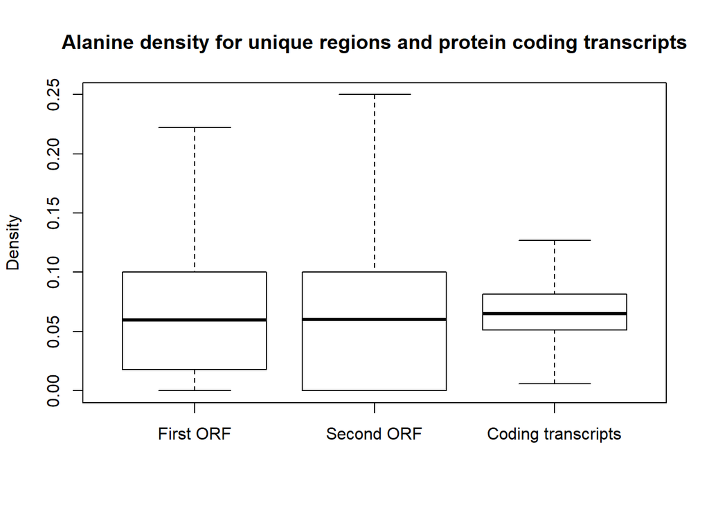

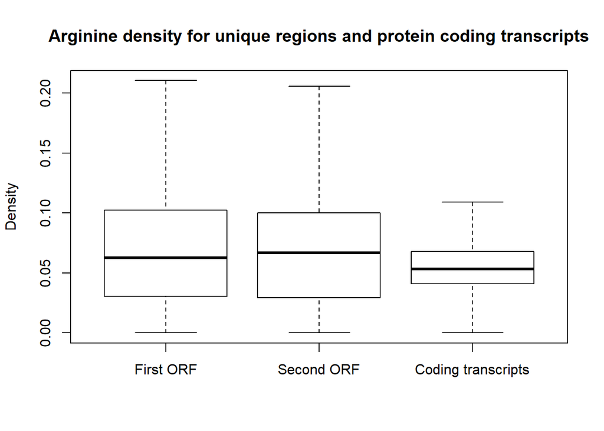

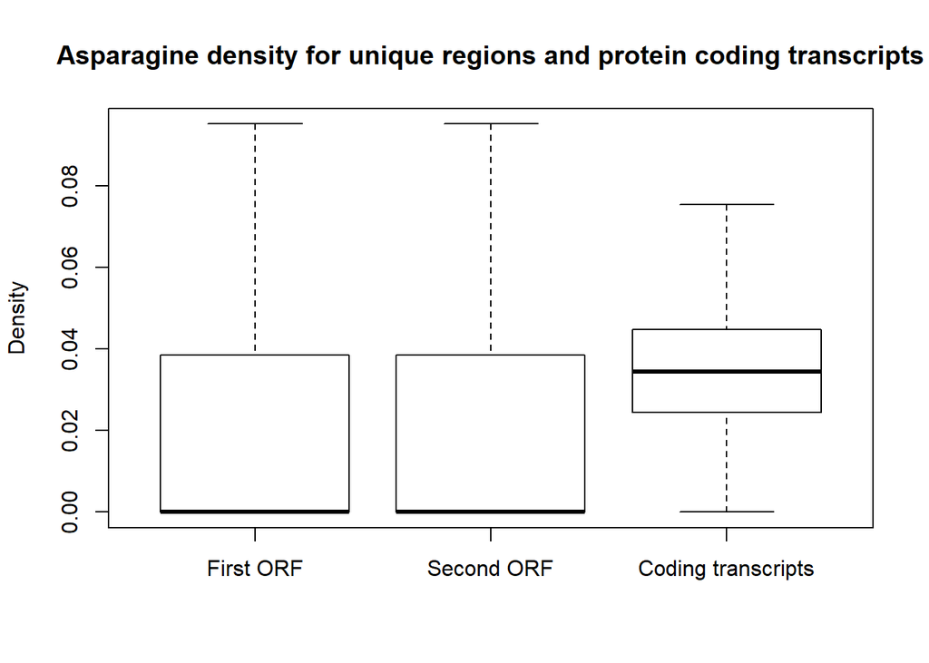

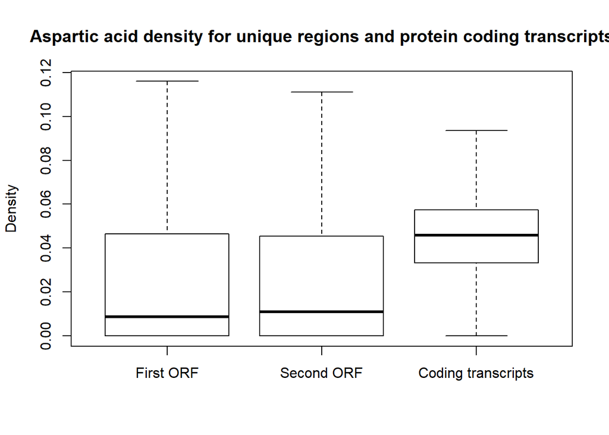

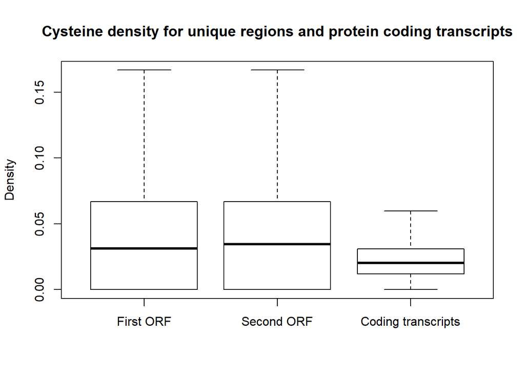

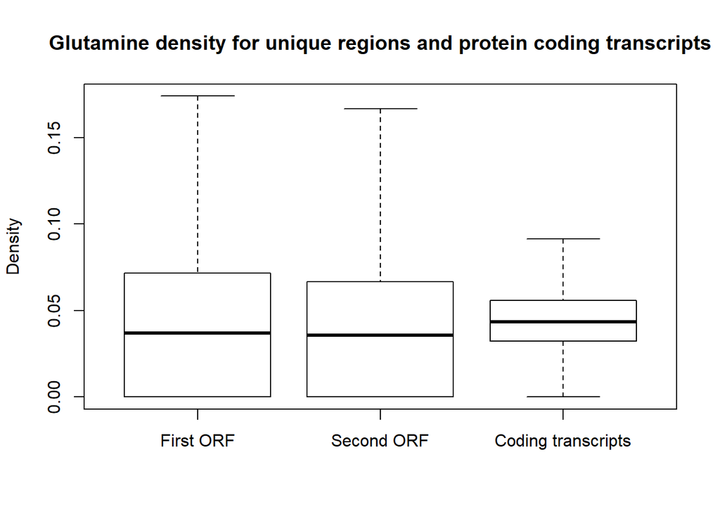

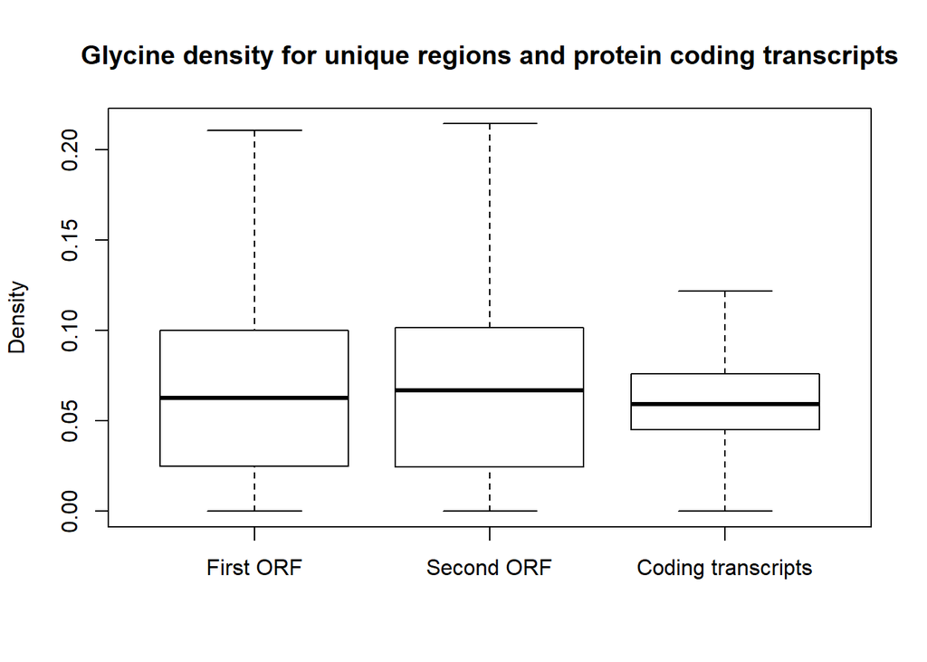

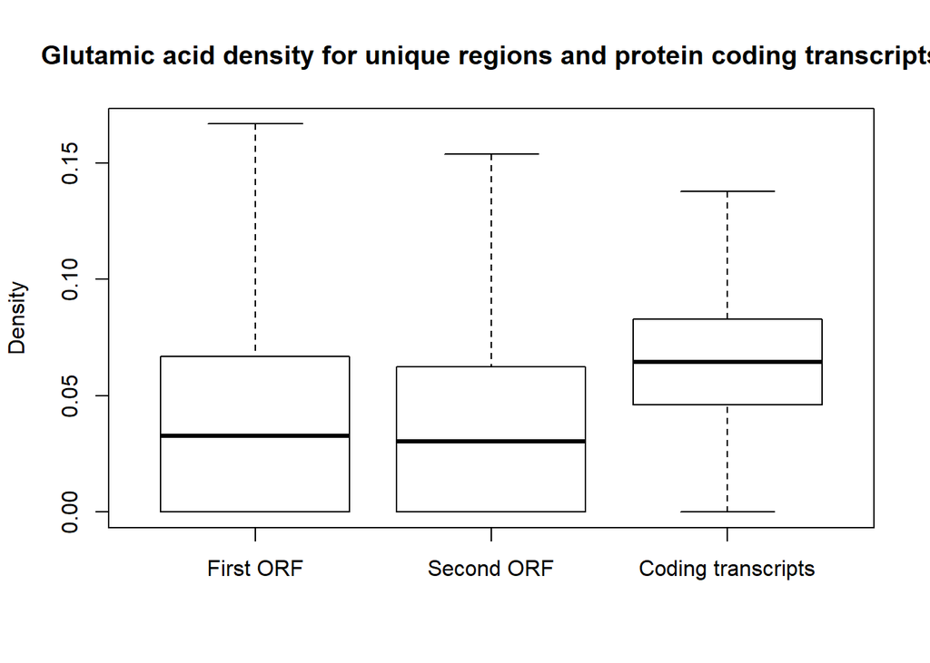